# Shape -> Tree

ryamada

2017年9月11日

# 1 Overview

- Make a triangle mesh of an object homeomorphic to S2 (sphere): $M_o$ .
- Calculate graph distance matrix of $M_o$ ($D(M_o)$). This matrix is a representation of the shape and the goal of this note is to express this distance matrix information in a tree structure.
- Calculate the shortest path from a vertex ($\rho$ (root vertex)) to all vertices. Then Make a tree graph that is a subgraph of $M_o$ whose edges are in the shortest paths: $T_o$.
- Label the vertices with the graph distance from $rho$: Z(v) .
- Spherize the mesh on to S2 : $M_s$ . The tree counter part is $T_s$ .
- Open up the sphere to $R^2$ plane; Riemann sphere ( https://en.wikipedia.org/wiki/Riemann_sphere ) ; select a vertex of mesh on $M_s$ and put the verteces on the origin of $R^2$ plane: $M_r$ . The tree counter part is $T_r$ .
- Make a cycle starting from $rho$ and returning to $rho$: Select an edge of edges of $rho$, walk “around” the $T_* (T_o,T_s, T_r)$ clockwise where all edges shoud be walked on both sides.
- Add additional nodes and edges to the tree with label values on the nodes so that a definition of distance on the tree represents $D(M_o)$ . The definition of distance on the tree will be given afterwards.

# 2 $M_o$ and $M_s$

Let’s make a 3D object with its spherized counterpart for practice.

```r
my.cell.sim.3 <- function (n = 5, k = 5, n.mesh = 32, n.step = 50, scale.shift = 0.1,
    scale.rotation1 = 0.1, scale.rotation2 = 0.1, scale.shear = 0.1,
    file.name = "hoge")
{
    A. <- matrix(runif(n^2), n, n)
    A.[1, 1] <- k
    B <- matrix(rnorm(n^2), n, n)
    xxx <- my.spherical.harm.mesh(A = A., B = B, n = n.mesh)

    M <- diag(rep(1, 4))
    M[1:3, 4] <- runif(3) * scale.shift
    theta1 <- runif(1) * scale.rotation1
    theta2 <- runif(1) * scale.rotation2
    Mm <- diag(rep(1, 3))
    Mm[1:2, 1:2] <- my.2d.rot(theta1) %*% Mm[1:2, 1:2]
    Mm[2:3, 2:3] <- my.2d.rot(theta2) %*% Mm[2:3, 2:3]
    M[1:3, 1:3] <- Mm
    M[4, 1:3] <- rnorm(3) * scale.shear
    for (i in 1:n.step) {
        A. <- A. + rnorm(n^2, 0, 0.05)
        xxx <- my.spherical.harm.mesh(A = A., n = n.mesh)
        xxxx <- cbind(xxx$v, rep(1, length(xxx$v[, 1])))
        rot.xxxx <- t(M %*% t(xxxx))
        rot.xxxx. <- rot.xxxx[, 1:3]/rot.xxxx[, 4]

        file.out <- paste(file.name, i, ".obj", sep = "")
        if(i == n.step){


                }

    }
    ret <- list(xyz.o = rot.xxxx.,xyz.s = my_sphere_tri_mesh(n.mesh)$xyz,face = xxx$f,edge=xxx$edge)
    #ret <- list(vb = t(rot.xxxx.),it=t(xxx$f),Ms=my_sphere_tri_mesh(n.mesh))
        return(ret)
}
my.plot3d.trimesh <- function(M,edge=NULL,overlap=TRUE){
  plot3d(M$xyz)
  if(is.null(edge)){
    segments3d(M$xyz[c(t(M$edge)),])
  }else{
    if(overlap){
      segments3d(M$xyz[c(t(edge)),],color="red")
      segments3d(M$xyz[c(t(M$edge)),],color="gray")
    }else{
      segments3d(M$xyz[c(t(edge)),])
    }
  }
}
```

```r
MoMs <- my.cell.sim.3(n.mesh=8)
MoMs.edges <- MoMs$edge
Mo <- list(xyz=MoMs$xyz.o,edge=MoMs$edge,face=MoMs$face)
Ms <- list(xyz=MoMs$xyz.s,edge=MoMs$edge,face=MoMs$face)
```

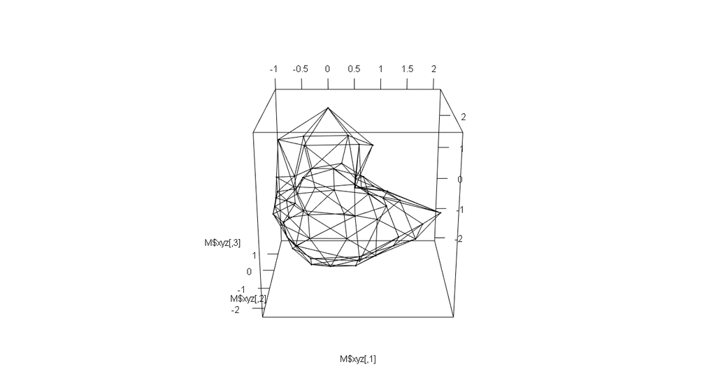

```r
my.plot3d.trimesh(Mo)
```

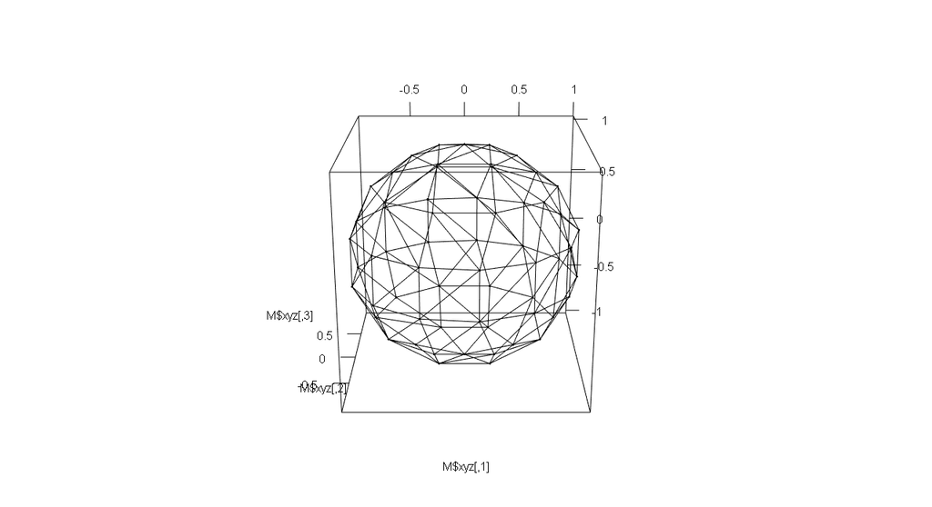

```r
my.plot3d.trimesh(Ms)
```

# 3 $D(M_o)$, graph distance matrix of $M_o$ and edge length

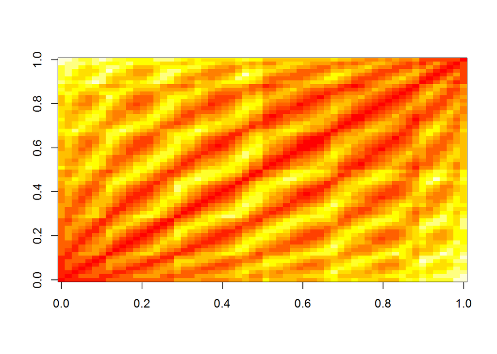

```r
g <- graph.edgelist(Mo$edge,directed=FALSE)
edge.length.o <- sqrt(apply((Mo$xyz[Mo$edge[,1],]-Mo$xyz[Mo$edge[,2],])^2,1,sum))
D.Mo <- distances(g,weights=edge.length.o)
image(D.Mo)
```

# 4 $\rho$ and the subgraph with shortest paths from $\rho$

```r
my.path.edge <- function(g,v,Edge.len){
    sh.path <- all_shortest_paths(g,v,weights=Edge.len,mode="out")
    len.path <- sapply(sh.path[[1]],length)
    n.path.edge <- sum(len.path)-length(len.path)
    path.edge <- matrix(0,2,n.path.edge)
    cnt <-1
    for(i in 1:vcount(g)){
        tmp <- sh.path[[1]][[i]]
        if(length(tmp)>1){
            tmp2 <- tmp[1:(length(tmp)-1)]
            tmp3 <- tmp[2:length(tmp)]
            tmp4 <- rbind(tmp2,tmp3)
            path.edge[,cnt:(cnt+length(tmp2)-1)] <- tmp4
            cnt <- cnt+length(tmp2)
        }
    }
    ret <- unique(t(path.edge))
    ret <- t(apply(ret,1,sort))
    return(ret)
}
```

```r
rho <- sample(1,1:length(Mo$xyz[,1]))
path.edge <- my.path.edge(g,rho,edge.length.o)
```

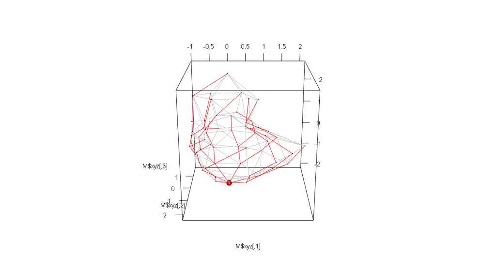

```r
my.plot3d.trimesh(Mo,path.edge,overlap=TRUE)
spheres3d(Mo$xyz[rho,],radius=0.1,color="red")
```

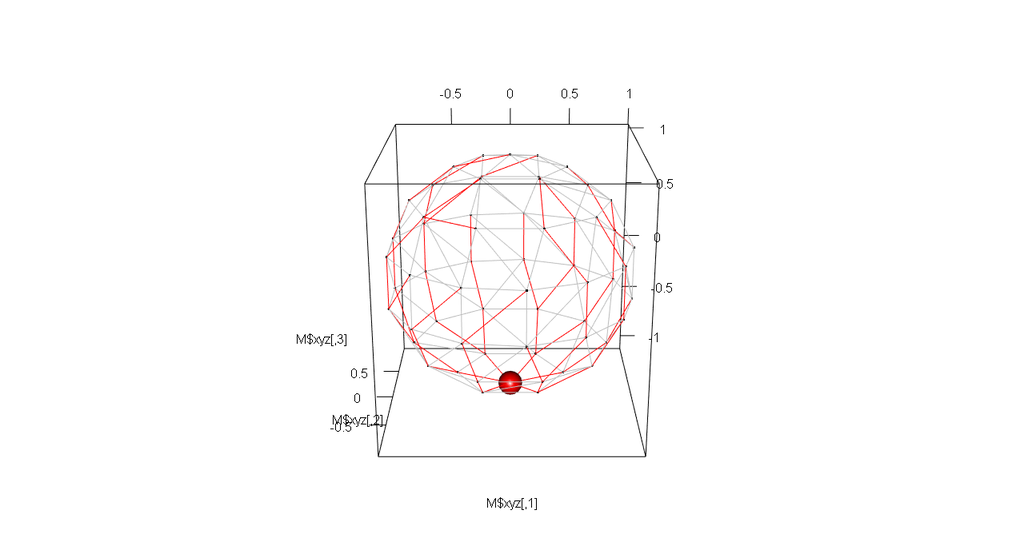

```r
my.plot3d.trimesh(Ms,path.edge,overlap=TRUE)
spheres3d(Ms$xyz[rho,],radius=0.1,color="red")
```

# 5 $Z(v)$; label value, distance from $\rho$

```r
Z <- D.Mo[rho,]
my.plot3d.trimesh(Mo,path.edge,overlap=TRUE)
spheres3d(Mo$xyz[rho,],radius=0.1,color="red")
spheres3d(Mo$xyz,radius=Z/max(Z)*0.1)
```

[output not shown]

# 6 Plane graph with Riemann sphere transformation

Select a triangle face that should corresponds to the out-most triangle when opened on to $R^2$ plane.

Rotate $M_s$ so that the selected face comes to the direction (0,0,1).

```r
# Riemann sphere transformation
my.Sp2Plane <- function(X){
  tmp <- X[,1] + 1i * X[,2]
  ang <- Arg(tmp)
  R <- 2*(Mod(tmp))/(1-X[,3])
  return(list(r=R,ang=ang))
}
# Utility fx: outer product of 3d vectors
my.outer.3dv <- function(u,v){
  return(c(u[2]*v[3]-u[3]*v[2],u[3]*v[1]-u[1]*v[3],u[1]*v[2]-u[2]*v[1]))
}

# Rotation that rotates a vector u to a vector v
# Rotation can be calculated with the axis vector with angle

my.3drotation.quaternion <- function(u,v){
  out <-my.outer.3dv(u,v)
  out <- out/sqrt(sum(out^2))
  angle <- acos(sum(u*v)/(sqrt(sum(u^2)*sqrt(sum(v^2)))))
  cos(angle/2) + sin(angle/2) * (Hi*out[1]+Hj*out[2]+Hk*out[3])
}

my.3drotation <- function(X,u,v){
  q <- my.3drotation.quaternion(u,v)
  tmp <- X[,1] * Hi + X[,2] *Hj + X[,3] * Hk
  ret <- q * tmp * Conj(q)
  return(cbind(i(ret),j(ret),k(ret)))
}
# The faceid-th face triangle is the outer most and the planar graph is drawn on the plane. Ms is trianglular mesh on the sphere. faceid is an integer. k is magnification factor of the outer most triangle.
my.planegraph <- function(Ms,faceid,k=1.1){
  face.v <- Ms$face[faceid,]

  face.xyz <- Ms$xyz[face.v,]
  direc <- apply(face.xyz,2,mean)
  direc <- direc/sqrt(sum(direc^2))
  xyz <- my.3drotation(Ms$xyz,direc,c(0,0,1))
  rang.complex <- my.Sp2Plane(xyz)
  max.R <- max(rang.complex$r)
  inside.max.R <- max(rang.complex$r[-face.v])

  face.v.ang <- rang.complex$ang[face.v]
  tmp1 <- cos((face.v.ang[1]-face.v.ang[2])/2)
  tmp2 <- cos((face.v.ang[1]-face.v.ang[3])/2)
  tmp3 <- cos((face.v.ang[2]-face.v.ang[3])/2)
  k2 <- min(abs(c(tmp1,tmp2,tmp3)))
  rang.complex$r[Ms$face[faceid,]] <- inside.max.R/k2 * k
  tmp <- rang.complex$r * exp(1i * rang.complex$ang)
  return(cbind(Re(tmp),Im(tmp)))
}

# Plot the planar graph
# When edge=NULL, all edges are drawn
# When edge is given as 2-column matrix, the given edges only are drawn (overlap=FALSE) or are highlighted (overlap=TRUE).
my.plot.plane.graph <- function(Mr,faceid,edge=NULL,overlap=TRUE){
  vs <- sort(Mr$face[faceid,])
  if(is.null(edge)){
    edge <- Mr$edge
    plot(Mr$xyz,pch=20,cex=0.1)
    edge1 <- edge
    segments(Mr$xyz[edge1[,1],1],Mr$xyz[edge1[,1],2],Mr$xyz[edge1[,2],1],Mr$xyz[edge1[,2],2])
  }else{
    if(overlap){
      edge.ori <- Mr$edge
      plot(Mr$xyz,pch=20,cex=0.1)
      edge1 <- edge.ori
      segments(Mr$xyz[edge1[,1],1],Mr$xyz[edge1[,1],2],Mr$xyz[edge1[,2],1],Mr$xyz[edge1[,2],2],col="gray")
      edge1 <- edge
      segments(Mr$xyz[edge1[,1],1],Mr$xyz[edge1[,1],2],Mr$xyz[edge1[,2],1],Mr$xyz[edge1[,2],2],col="red")
    }else{
      plot(Mr$xyz,pch=20,cex=0.1)
      edge1 <- edge
      segments(Mr$xyz[edge1[,1],1],Mr$xyz[edge1[,1],2],Mr$xyz[edge1[,2],1],Mr$xyz[edge1[,2],2])
    }
  }
}
```

Select a face having $\rho$.

```r
face.with.rho <- which(apply(Ms$face-rho,1,prod)==0)
face.id <- sample(face.with.rho,1)
#face.id <- sample(1:length(Ms$face[,1]),1)
Mr <- list(xyz = my.planegraph(Ms,face.id),edge=Ms$edge,face=Ms$face)
```

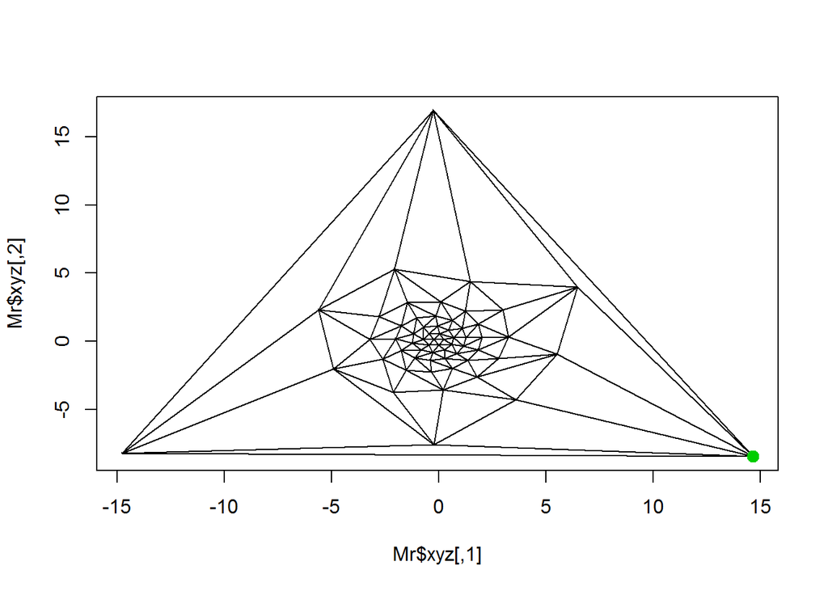

```r
my.plot.plane.graph(Mr,face.id)
points(Mr$xyz[rho,1],Mr$xyz[rho,2],pch=20,cex=2,col=3)
```

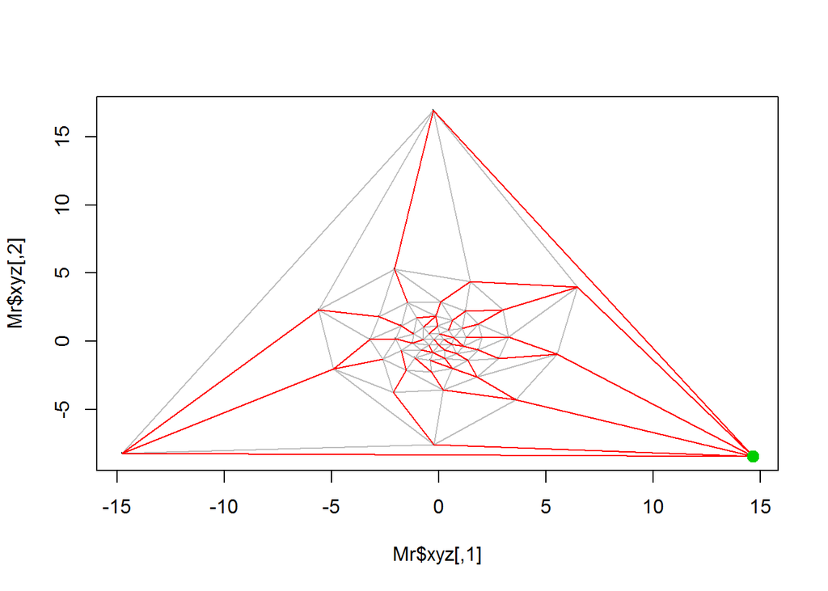

```r
my.plot.plane.graph(Mr,face.id,edge=path.edge)
points(Mr$xyz[rho,1],Mr$xyz[rho,2],pch=20,cex=2,col=3)
```

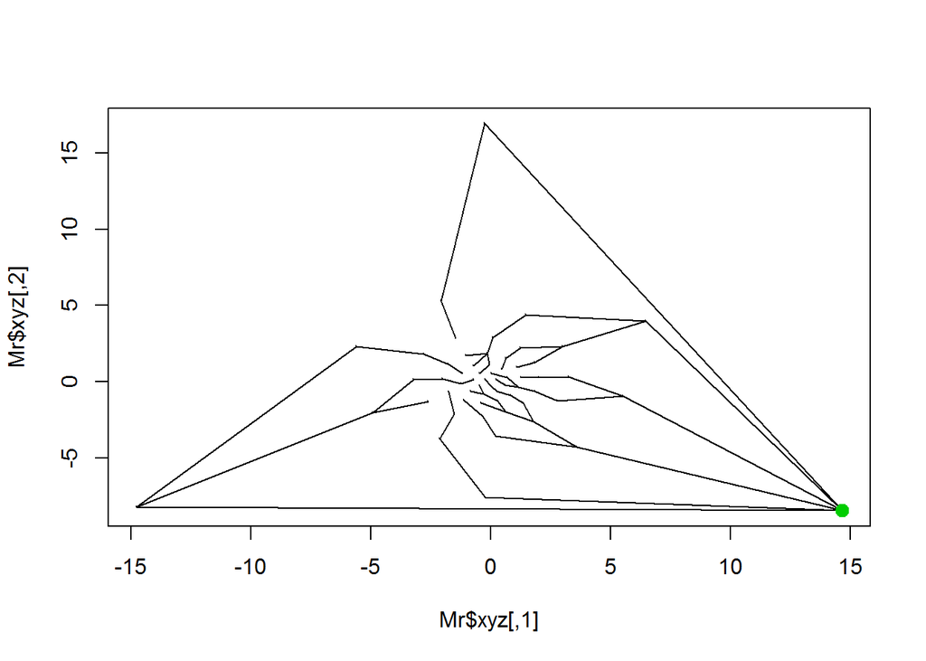

```r
my.plot.plane.graph(Mr,face.id,edge=path.edge,overlap=FALSE)
points(Mr$xyz[rho,1],Mr$xyz[rho,2],pch=20,cex=2,col=3)
```

# 7 Cycle around the tree

```r
Tr <- list(xyz = Mr$xyz,edge=path.edge,face=Mr$face)
```

```r
my.cycle.tree <- function(Mr,rho){
  edge2 <- rbind(Mr$edge,Mr$edge[,2:1])
  e.vec <- Mr$xyz[edge2[,2],]-Mr$xyz[edge2[,1],]
  e.vec. <- e.vec[,1] + 1i * e.vec[,2]
  ang <- Arg(e.vec.)
  edge.from <- edge.to <- list()
  for(i in 1:length(Mr$xyz[,1])){
    edge.from[[i]] <- which(edge2[,1]==i)
    edge.to[[i]] <- which(edge2[,2]==i)
  }
  loop <- TRUE
  edge.order <- rep(NA,length(edge2[,1]))
  edge.order[1] <- edge.from[[rho]][1]
  edge.from[[rho]] <- edge.from[[rho]][-1]
  current.edge <- edge.order[1]
  cnt <- 1
  while(loop){
    next.node <- edge2[current.edge,2]
    in.ang <- ang[current.edge]
    candidate.edge <- edge.from[[next.node]]
    candidate.ang <- ang[candidate.edge]
    tmp <- candidate.ang - in.ang - pi
    #tmp2 <- which(tmp < 0)
    #tmp[tmp2] <- tmp[tmp2] + 2 * pi
    #print(tmp)
    if(length(candidate.edge)==0){
      loop <- FALSE
    }else{
      if(length(candidate.edge)==1){
        selected.edge <- 1
      }else if(length(candidate.edge)>1){
        selected.edge <- order(tmp)[2]
      }
      edge.order[cnt+1] <- candidate.edge[selected.edge]
      edge.from[[next.node]] <- edge.from[[next.node]][-selected.edge]
      cnt <- cnt+1
      current.edge <- edge.order[cnt]
      if(cnt==length(edge.order)){
        loop <- FALSE
      }
    }




  }
  node.order <- c(edge2[edge.order,1],rho)
  return(list(e=edge.order,v=node.order))
}
```

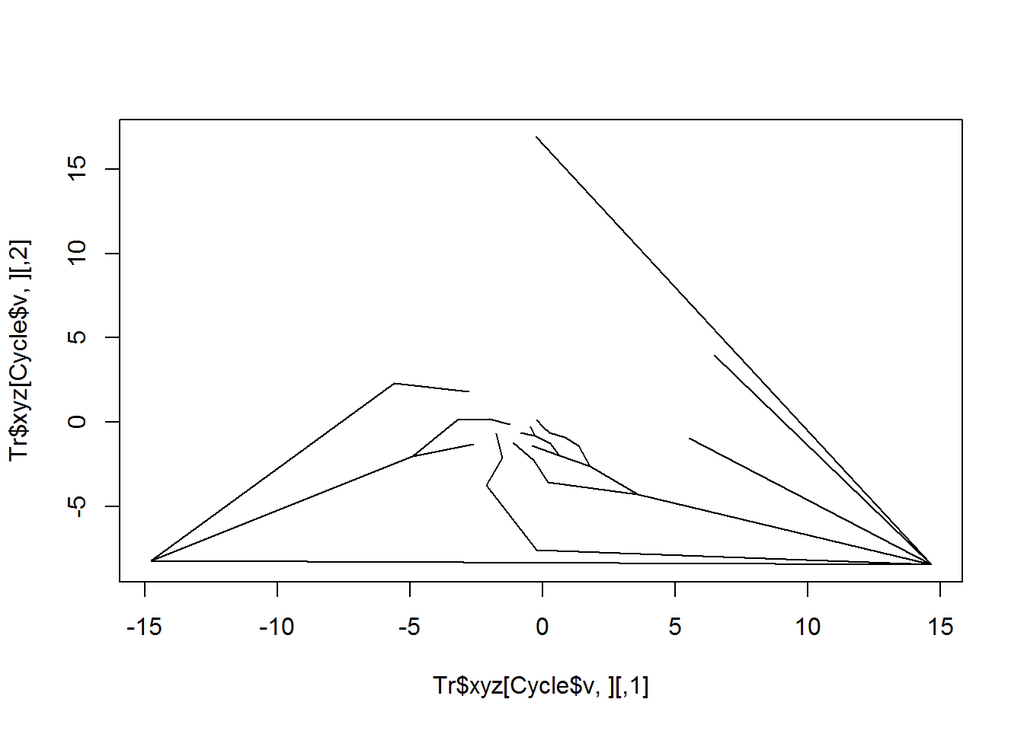

```r
Cycle <- my.cycle.tree(Tr,rho)
plot(Tr$xyz[Cycle$v,],type="l")
```